# Plotting Assignment

Maikol Monticelli

2025-02-09

# Loading dependencies

```r
# Loading some packages for plotting
library(readr)
library(ggplot2)
library(scales)
library(dplyr)
library(tidyr)
library(ThemePark)
library(patchwork)
library(janitor)
library(knitr)
library(kableExtra)
```

# Data generation

```r
# Setting the random seed
set.seed(123)

# Simulating the data
n <- 100
game_agression <- data.frame(
  x = rnorm(n, mean = 50, sd = 10),
  y = rnorm(n, mean = 100, sd = 20)
)
```

# Plotting

## Bad Plot

### Coding the bad plot

```r
plot_bad <- ggplot(game_agression, aes(x = x, y = y)) +
# Adding  extreme colors and making the lining worse by dotting it
  geom_point(color = "pink", size = 7, shape = 8) +
  geom_smooth(method = "lm", se = FALSE, color = "red", linetype = "dotted") +
# The void theme has no axes, ticks or gridlines
  theme_void() +
  ggtitle("Connection between games and agression")
```

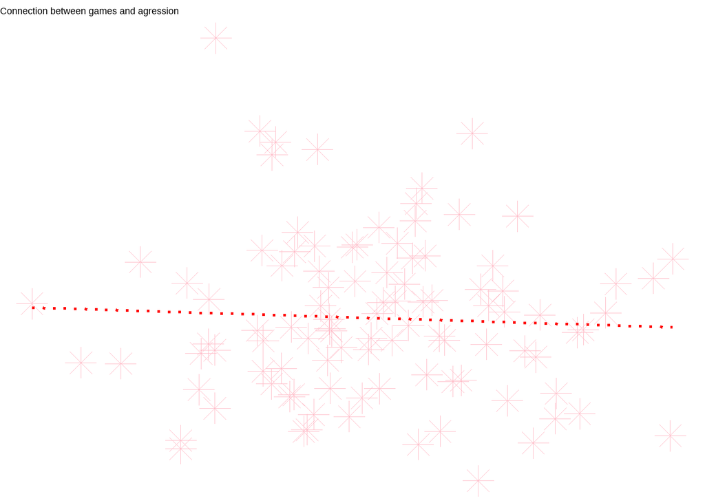

```r
# Printing and saving the bad plot
print(plot_bad)
```

```r
ggsave("plot_bad.png",plot = plot_bad,bg= "white")
```

### Why is this a bad plot?

- Only the title but no more information given, it makes the interpretation really difficult.
- Choosing a theme that is not good for the type of plot, by completely wiping the axes, ticks and gridlines.
- Really distracting colors and dot type, this makes the data look cluttered and distracting
- The colors are not color blindness friendly

## Good plot

### Coding the good plot

```r
plot_good <- ggplot(game_agression, aes(x = x, y = y)) +
  geom_point(color = "steelblue", size = 3, alpha = 0.7) +
# Regression line with confidence interval
  geom_smooth(method = "lm", se = TRUE, color = "darkblue") +
  labs(
# Defining title,x,y and caption
     title = "The interplay between games and agression",
    x = "Game Time in min",
    y = "Agression Value",
    caption = "The data was simulated thanks to R, n=100"
  ) +
  theme_minimal(base_size = 14) +
# Centering and making the Title appealing
  theme(
    plot.title = element_text(face = "bold", hjust = 0.5),
    plot.caption = element_text(size = 10, hjust = 1)
  )
```

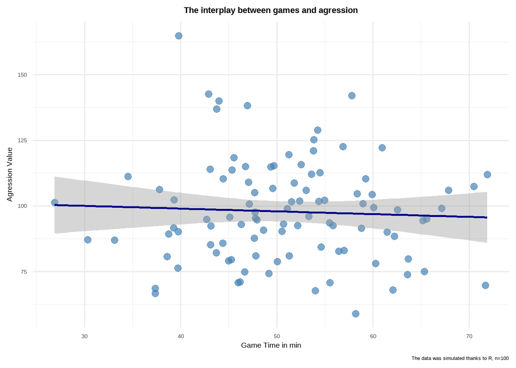

```r
# Printig the good plot
print(plot_good)
```

```r
ggsave("plot_good.png",plot = plot_good, bg= "white")
```

### Why is this a good plot?

- Clear description of x and y axes and a detailed title to give the reader all the information needed.
- Good coloring and making it okay for everyone, taking the most common color blindness in consideration.
- Choosing a simple and modern theme to make it more attractive.
- Slightly transparent points so that the data doesn’t seem cluttered and you can see layering dots.
- Decent scaling values
- Adding the confidenc interval to make the interpretation easier.

# Grading

In my opinion I did a a decent job therefore deserving a 4,5-5 for the plotting.

- The bad plot is really messy and unreadable.
- The good plot is clear and readable.